# PSYCH2840_correlations

## Week 10: Understanding bivariate correlations

To help you get an intuitive sense of what a correlation represents, I created fake data to show what positive, negative and zero correlations look like, what a correlation coefficient (r value) actually represents, and how small sample sizes are more influenced by outliers.

Let’s start with a perfect correlation - i.e. a r value of 1. What does a perfect positive correlation look like?

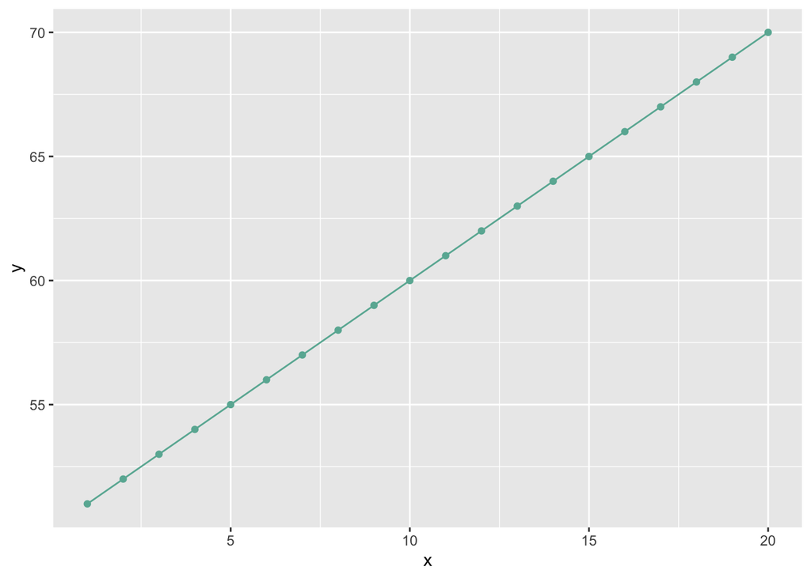

```r
library(ggplot2)

x = 1:20
y = 51:70
d = data.frame(x, y)

ggplot(data = d, aes(x = x, y = y)) + geom_point(color='#69b3a2') +
  geom_line(color='#69b3a2')
```

A correlation of 1 means there is a perfect linear relationship between x and y. It also means if we know X we can perfectly predict Y (within our sample).

Positive correlations mean when X goes up, Y goes up. This means the regression line will have a positive slope.

**Remember:** Just because two variables are correlated, doesn’t mean they causally related (i.e. variable X causes variable Y or vice versa) - even if you have a perfect correlation.

What about a negative correlation with an r value of -1?

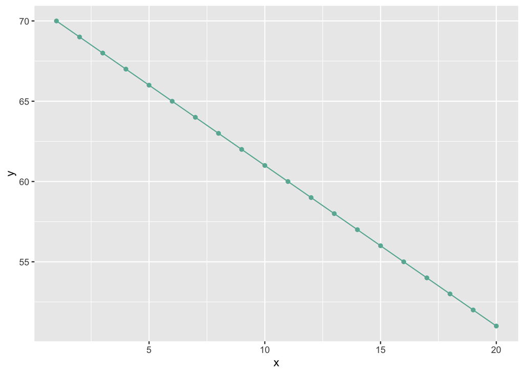

```r
x = 1:20
y = 70:51
d = data.frame(x, y)

ggplot(data = d, aes(x = x, y = y)) + geom_point(color='#69b3a2') + geom_line(color='#69b3a2')
```

Again, there is a perfect linear relationship between x and y but it’s going in the opposite direction.

Negative correlations mean when X goes up, Y goes down. This means the regression line will have a negative slope.

We basically never have a correlation coeffient of 1 - in psychology, our correlations are often much lower. What does this look like?

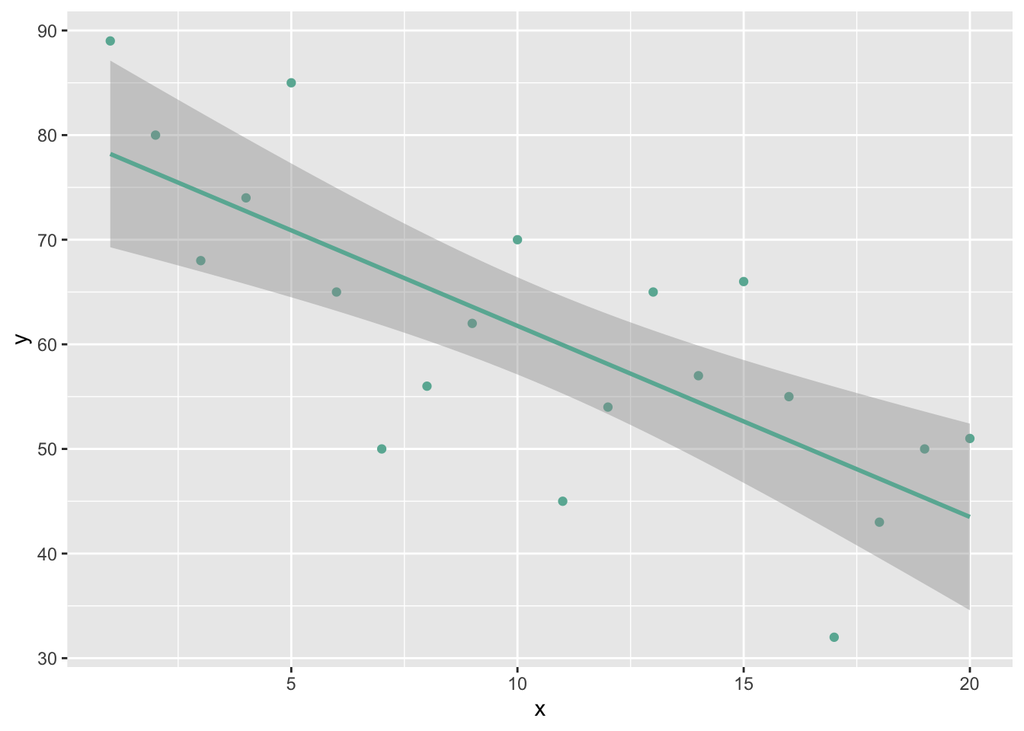

```r
x = 1:20
y = c(89, 80, 68, 74, 85, 65, 50, 56, 62, 70, 45, 54, 65, 57, 66, 55, 32, 43, 50, 51)
c = cor(x,y)
d = data.frame(x, y)

ggplot(data = d, aes(x = x, y = y)) + geom_point(color='#69b3a2') +
  geom_smooth(method='lm', color='#69b3a2')
```

This is a correlation of -0.75. It’s still strong - if we know a value of x, we can pretty accurately predict our value of y (with some error). It’s negative, so as x goes up, y goes down.

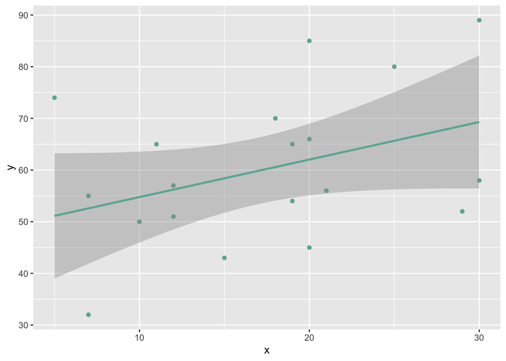

```r
x = c(30, 25, 30, 5, 20, 19, 10, 21, 29, 18, 20, 19, 11, 12, 20, 7, 7, 15, 10, 12)
y = c(89, 80, 58, 74, 85, 65, 50, 56, 52, 70, 45, 54, 65, 57, 66, 55, 32, 43, 50, 51)
c = cor(x,y)
d = data.frame(x, y)

ggplot(data = d, aes(x = x, y = y)) + geom_point(color='#69b3a2') +
  geom_smooth(method='lm', color='#69b3a2')
```

This is a correlation of +0.39. It’s a smaller correlation so there is more error in our prediction. We can tell it would be smaller because the dots are more spread out from our regression line. There is a less consistent pattern between x and y - although the regression line still trends up, suggesting a slight (non-significant) positive relationship

What does a zero correlation look like?

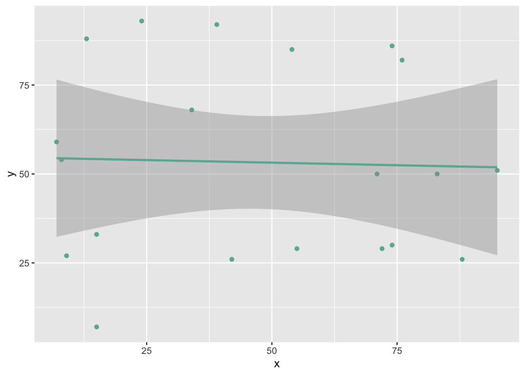

```r
set.seed(10)
x = sample(1:100, 20, replace = TRUE)
y = sample(1:100, 20, replace = TRUE)
c = cor(x, y)

d = data.frame(x, y)

ggplot(data = d, aes(x = x, y = y)) + geom_point(color='#69b3a2') + geom_smooth(method='lm', color='#69b3a2')
```

You can see - the regression line is basically flat. The r value is -0.03. This means we cannot predict y with x - or that knowing x tells us nothing about y.

Let’s look at some fake data to get a sense of what a correlation is actually measuring. Imagine this is grade data from five students on their midterm and final exams. Can we predict someones final exam grade based on their midterm grade?

```r
midterm = c(58, 64, 66, 70, 72)
xbar_m = mean(midterm)
final = c(72, 80, 79, 85, 90)
xbar_f = mean(final)
Student = c(1:5)
grades = data.frame(Student, midterm, final)

grades_cor = cor(midterm, final)
grades
```

```
##   Student midterm final
## 1       1      58    72
## 2       2      64    80
## 3       3      66    79
## 4       4      70    85
## 5       5      72    90
```

If you look at each student’s scores, can you predict what direction the correlation will go in? Do you think it will be a strong or weak correlation?

Ask yourself - Did the students with the highest grades on the midterm get the highest grades on the final? It seems that way - student 5 had the highest midterm grade and highest final grade. And student 1 had the lowest midterm grade and lowest final grade. This pattern is consistent across all students. This suggests there is a positive relationship between the two variables, and that this relationship is strong.

When we calculate the correlation we get +0.97. Exactly what we predicted - a positive, strong relationship.

What about this data? What do you predict is going on here?

```r
midterm = c(58, 62, 64, 70, 72)
xbar_m = mean(midterm)
final = c(90, 82, 85, 70, 74)
xbar_f = mean(final)
Student = c(1:5)
grades = data.frame(Student, midterm, final)

grades_cor = cor(midterm, final)
grades
```

```
##   Student midterm final
## 1       1      58    90
## 2       2      62    82
## 3       3      64    85
## 4       4      70    70
## 5       5      72    74
```

The correlation for this dataset is -0.92.

What about this dataset?

```r
midterm = c(58, 62, 64, 70, 72)
xbar_m = mean(midterm)
final = c(80, 72, 92, 95, 78)
xbar_f = mean(final)
Student = c(1:5)
grades = data.frame(Student, midterm, final)

grades_cor = cor(midterm, final)
grades
```

```
##   Student midterm final
## 1       1      58    80
## 2       2      62    72
## 3       3      64    92
## 4       4      70    95
## 5       5      72    78
```

The pattern is less clear for this dataset. Student 5 had the highest grade on the midterm, and the second lowest grade on the final. Student 1 had the lowest grade on the midterm, and the third highest grade on the final. Student 4 had the second highest grade on the midterm, and the highest grade on the final. Maybe there is a pattern here, but it’s less clear. And when we look at the correlation: +0.31, you can see that it’s a small (and not significant) relationship.

This last example also tells us something important about sample size and statistical validity. Even though a correlation of +0.31 might seem meaningful, we also have to consider the sample size. In this case, our sample size was 5 students, so when we look up the probability of getting this large of a correlation by chance, it’s pretty high! When interpreting correlation coeffients, we should look at the p-value (or confident interval) to determine whether our r value is statistically significant.

Remember: Small samples are more influenced by outliers - we may get what seems like a large correlation by chance.

Let’s go through an example. I have randomly sampled 10 values for x, and 10 values for y. There should theoretically be no relationship between these two variables because they were chosen randomly (and independently from each other).

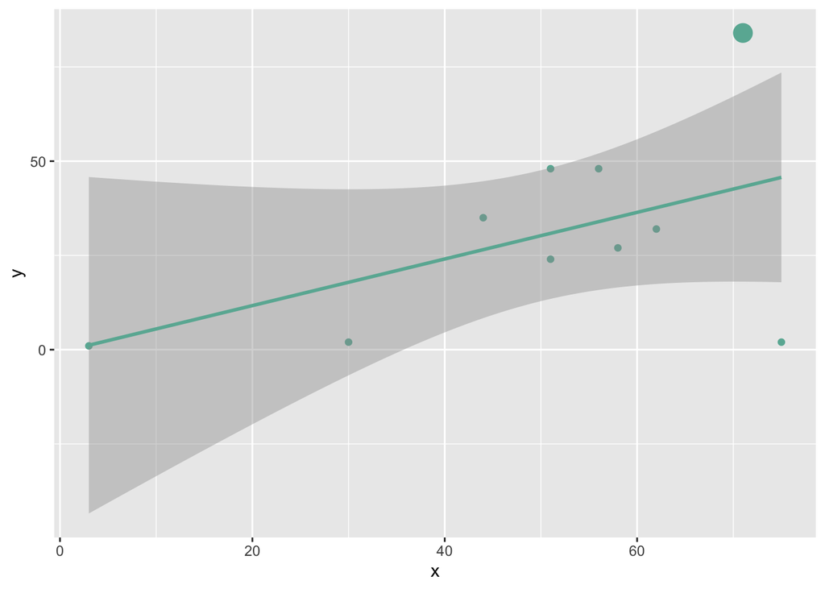

```r
set.seed(4)
x = sample(1:100, 10, replace = TRUE)
y = sample(1:100, 10, replace = TRUE)
random_corr = cor.test(x, y)

d = data.frame(x, y)

ggplot(data = d, aes(x= x, y = y)) + geom_point(color='#69b3a2') + geom_smooth(method='lm', color='#69b3a2') + geom_point(data=subset(d, y == max(d$y)), aes(x=x, y=y), color='#69b3a2',size=5)
```

In this case, I got a correlation of +0.5 - completely due to chance. You can see that one of my data points (the dot that is bigger in the right upper corner) is very high on both variables - this is an outlier, and it’s making my correlation a lot stronger. Let’s see what happens when I remove that datapoint.

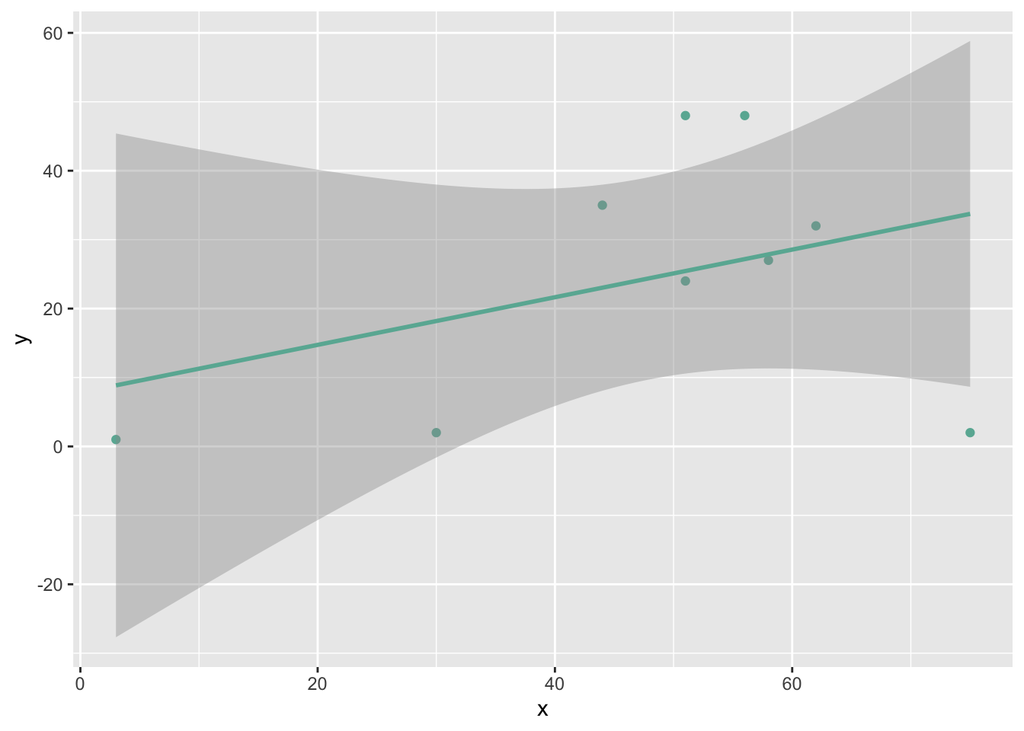

```r
new_d = subset(d, y < max(d$y))
random_corr = cor.test(new_d$x, new_d$y)


ggplot(data = new_d, aes(x= x, y = y)) + geom_point(color='#69b3a2') + geom_smooth(method='lm', color='#69b3a2')
```

Now our correlation is +0.38 - it dropped by a lot, from just removing that one participant. We still have a positive correlation, but it’s less strong.

**Note:** Neither of these two correlation values were statistically significantly different from zero, because our degrees of freedom (sample size - 1) is so low.

What happens when I randomly select 100 numbers for x and y?

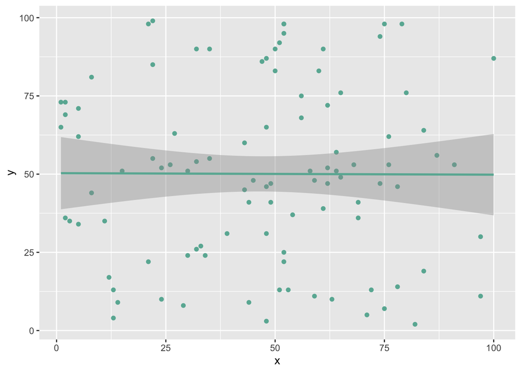

```r
set.seed(4)
x = sample(1:100, 100, replace = TRUE)
y = sample(1:100, 100, replace = TRUE)
random_corr = cor.test(x, y)

d = data.frame(x, y)

ggplot(data = d, aes(x= x, y = y)) + geom_point(color='#69b3a2') + geom_smooth(method='lm', color='#69b3a2')
```

You can see, the regression line is flat, and our correlation value is 0. Even though we have a few datapoints with high x’s and y’s, there are many more data points so these outliers don’t have as much of an impact on our r value.

As we learned in week 3, the larger our sample size, the more confident we are in our estimates (whether they are frequency, correlational, or effect size estimates).